# EDA - EV Charging Stations

### Group Data for Insights

```python
# Sorting & Grouping Data
# ev_sorted = ev.sort_values(by=(5), ascending=[False])
# DF_sorted

# Group Data by Region
ev_region = ev.groupby(['region', 'category', 'mode'])['category'].count()
print(ev_region)

# Group Data by Region
ev2 = ev.groupby(['region', 'parameter', 'mode'])['category'].count()
print(ev2)

# # Groupby multiple columns and aggregate()
# result = ev_groups.groupby(['Courses','Fee'])['Duration'].aggregate('count')
# print(result)
```

```
region             category          mode
Australia          Historical        EV      10
Belgium            Historical        EV      18
Brazil             Historical        EV       8
Canada             Historical        EV      20
Chile              Historical        EV      22
China              Historical        EV      16
                   Projection-APS    EV       8
                   Projection-STEPS  EV       8
Denmark            Historical        EV      20
Europe             Projection-APS    EV       8
                   Projection-STEPS  EV       8
Finland            Historical        EV      18
France             Historical        EV      20
Germany            Historical        EV      20
Greece             Historical        EV       7
Iceland            Historical        EV      15
India              Historical        EV      11
                   Projection-APS    EV       8
                   Projection-STEPS  EV       8
Indonesia          Historical        EV       4
Italy              Historical        EV      20
Japan              Historical        EV      20
Korea              Historical        EV      12
Mexico             Historical        EV      11
Netherlands        Historical        EV      22
New Zealand        Historical        EV       9
Norway             Historical        EV      23
Other Europe       Historical        EV      20
Poland             Historical        EV      16
Portugal           Historical        EV      22
Rest of the world  Projection-APS    EV       8
                   Projection-STEPS  EV       8
South Africa       Historical        EV      10
Spain              Historical        EV      19
Sweden             Historical        EV      20
Switzerland        Historical        EV      20
Thailand           Historical        EV      10
USA                Historical        EV      19
                   Projection-APS    EV       8
```

[output cut: 27 more lines]

```
New Zealand        EV charging points  EV       9
Norway             EV charging points  EV      23
Other Europe       EV charging points  EV      20
Poland             EV charging points  EV      16
Portugal           EV charging points  EV      22
Rest of the world  EV charging points  EV      16
South Africa       EV charging points  EV      10
Spain              EV charging points  EV      19
Sweden             EV charging points  EV      20
Switzerland        EV charging points  EV      20
Thailand           EV charging points  EV      10
USA                EV charging points  EV      35
United Kingdom     EV charging points  EV      21
World              EV charging points  EV      40
Name: category, dtype: int64
```

```python
# Select data by charging points in 2021
ev2 = ev[(ev['parameter'] == 'EV charging points') & (ev['year'] == 2021)]
print('Shape of new data frame: ' + str(ev2.shape))


print('\nRegions with most EV Charging points in 2021:')
ev2['region'].value_counts().nlargest(100)

ev2.groupby('value')

# ev2.head(100)
# ev2['year'].value_counts()
```

```
Shape of new data frame: (86, 8)

Regions with most EV Charging points in 2021:
```

```
<pandas.core.groupby.generic.DataFrameGroupBy object at 0x7f79b59cd060>
```

```python
# Sorting & Grouping Data
ev_sorted = ev.sort_values(by=('region'), ascending=[False])
print(ev_sorted)

# Group Data by Region
ev_region = ev.groupby(['region', 'unit'])['region'].count()
print(ev_region)

# Group Data by Region
ev2 = ev.groupby(['region', 'parameter', 'mode'])['category'].count()
print(ev2)

# # Groupby multiple columns and aggregate()
# result = ev_groups.groupby(['Courses','Fee'])['Duration'].aggregate('count')
# print(result)

# ev_groups.mean()
```

[output not shown]

[output cut: 11 more lines]

```
           stock                                152
Name: region, Length: 148, dtype: int64
region     parameter              mode
Australia  EV charging points     EV        10
           EV sales               Cars      21
           EV sales share         Cars      11
           EV stock               Cars      21
           EV stock share         Cars      11
                                            ..
World      Oil displacement Mbd   Vans      20
           Oil displacement Mlge  Buses     20
                                  Cars      20
                                  Trucks    20
                                  Vans      20
Name: category, Length: 546, dtype: int64
```

### Australia EV Charging Station EDA

1. Select all of the Australia EV Charging Station Data and inspect it. EV charging points

|  | powertrain | year | value |
| --- | --- | --- | --- |
| 38 | Fast | 2017 | 40.0 |
| 39 | Slow | 2017 | 440.0 |
| 44 | Fast | 2018 | 61.0 |
| 45 | Slow | 2018 | 670.0 |
| 54 | Fast | 2019 | 250.0 |
| 55 | Slow | 2019 | 1700.0 |
| 60 | Fast | 2020 | 350.0 |
| 61 | Slow | 2020 | 2000.0 |
| 70 | Fast | 2021 | 350.0 |
| 73 | Slow | 2021 | 2000.0 |

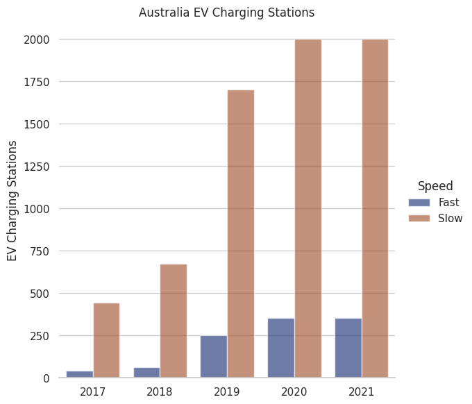

It is clear that there was a huge increase in the number of EV Charging Stations in Australia between 2018 and 2019 before the pandemic. Afterwards during lockdown there was not a great increase in the amount of charging stations within Australia. A possible reason is the pandemic.

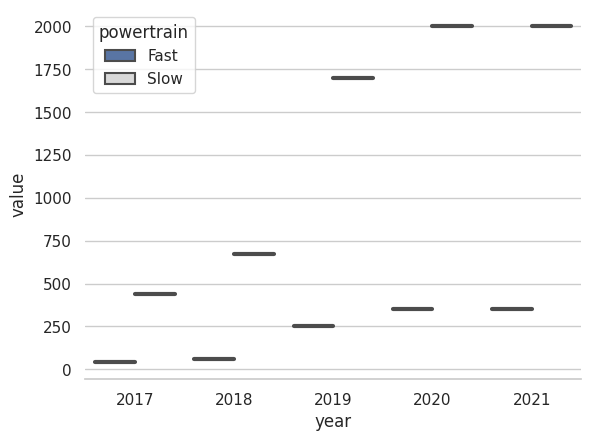

```python
# Draw a nested violinplot and split the violins for easier comparison
sns.violinplot(data=ev_aus, x="year", y="value", hue="powertrain",
               split=True, inner="stick", linewidth=3, orient = 'v',
               palette={"Fast": "b", "Slow": ".85"})
sns.despine(left=True)
```

[figure not shown]

[output not shown]

[figure not shown]

```python
# Horizontal barplot

import seaborn as sns
import matplotlib.pyplot as plt
sns.set_theme(style="whitegrid")

# Initialize the matplotlib figure
f, ax = plt.subplots(figsize=(6, 15))

# Load the example car crash dataset
crashes = sns.load_dataset("car_crashes").sort_values("total", ascending=False)

# Plot the total crashes
sns.set_color_codes("pastel")
sns.barplot(x="year", y="abbrev", data=ev,
            label="Total", color="b")

# Plot the crashes where alcohol was involved
sns.set_color_codes("muted")
sns.barplot(x="alcohol", y="abbrev", data=crashes,
            label="Alcohol-involved", color="b")

# Add a legend and informative axis label
ax.legend(ncol=2, loc="lower right", frameon=True)
ax.set(xlim=(0, 24), ylabel="",
       xlabel="Automobile collisions per billion miles")
sns.despine(left=True, bottom=True)
```